# Part II - PISA 2012 Data Presentation

## by Keith Obade

## Investigation Overview

> The goal of this presentation is to show the most important findings of this study. Many variables were examined to see which would affects on the students' total scores in maths, reading and science.

The key insights are:

- Mexico has the highest student count who participated with around 34000 students and Lischtestein with less than 1000 students.
- Most students chose the Agree choice then Strongly Agree, Disagree and lastly Strongly disagree. This shows that most students agree that the is motivation to studying.
- The strongest positive correlations can be observed between the scores of the different test areas math, reading, or science.If a student does well in one subject, it is likely that they will do well in another as well.
- Most countries performed slightly in the same region in all tests between 400 - 500 points with China being the best performing country in all tests while Peru was the least.
- Those who strongly disagreed on all 4 modes of motivation got the lowest scores which might the reason of low scores.

## Dataset Overview

> This is the PISA 2012 Dataset. PISA is the Program for International Student Assessments that allows countries to compare outcomes of the learning as students get close to finishing compulsory schooling.

> This is a survey of the skills and knowledge of students as they approach the end of compulsory education which looks at majorly how prepared the students are for life beyond school.

> It gives an assessment of reading, mathematics and science representing about 28 million 15-year-olds globally. Of those economies, 44 took part in an assessment of creative problem solving and 18 in an assessment of financial literacy.

## Number of Students per Country.

> Mexico has the highest students who participated with around 34000 students and Lischtestein with less than 1000 students. I used a horizontal barchart since I am representing categorical data and the variables are many so it is better to use the horizontal bar chart. Here I was looking for how many students were in the different countries and participated in the survey.

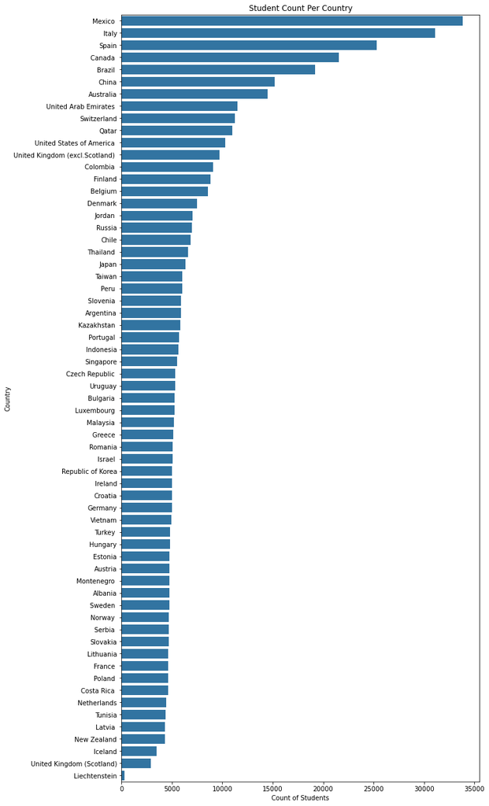

## Distribution of the Instrumental motivation ratings by the students.

> Most students chose the Agree choice then Strongly Agree, Disagree and lastly Strongly disagree. This shows that most students agree that the is motivation to studying.- Since I am representing Likert Scale categorical variables, I used bar charts to show how the different levels were performing against the count of students. This shows the relationship between the Instrumental Motivation modes against the number of students that chose each one of them.

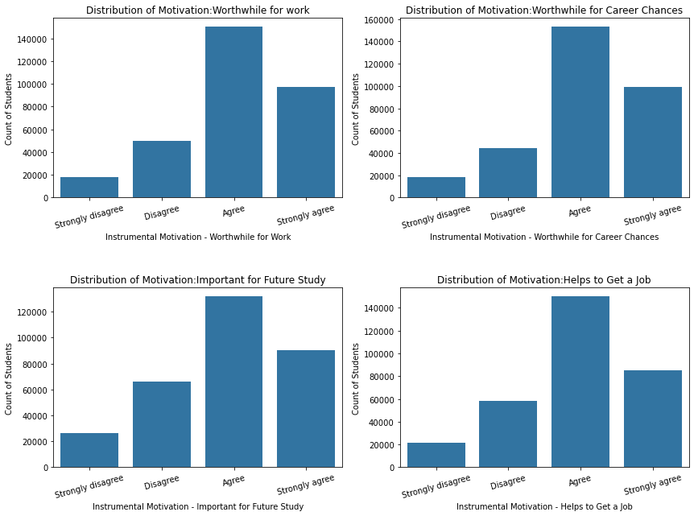

## Correlation of The Different Scores.

> The strongest positive correlations can be observed between the scores of the different test areas math, reading, or science.If a student does well in one subject, it is likely that they will do well in another as well. The correlation matrix also shows comparison of different qualitative variables including the Motivation, Attribution to failure, Sense of Belonging and Perseverance. It also shows the factors affecting the students scores(Sense of Belonging, Attributions of Failure in Maths Score, Motivation for Maths and Perseverance scores) are only weakly correlated with test scores. There are even negatively correlated factors with students' performance in the PISA test, though the correlation is rather weak. This could imply a problem with the factors affecting the student do not reflect on the student scores.

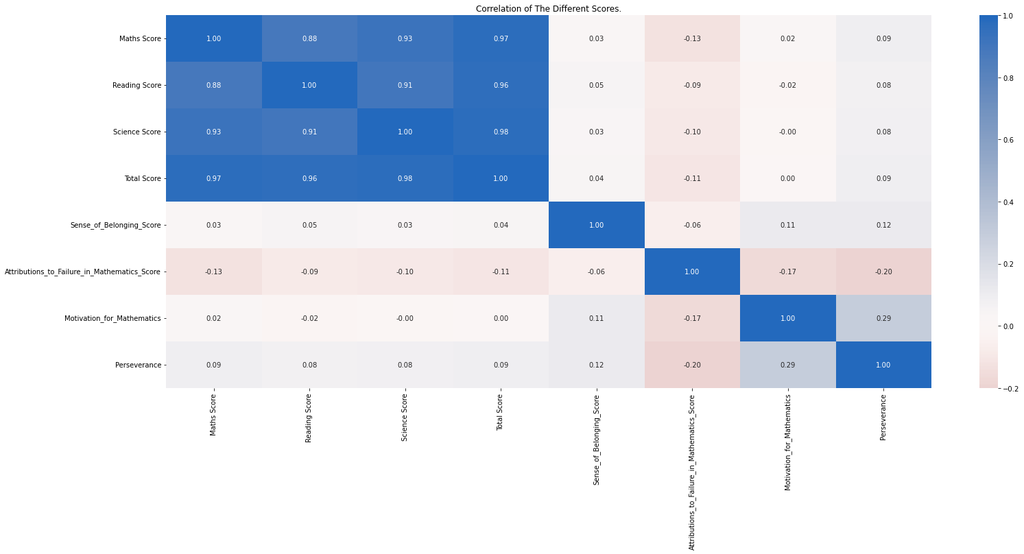

## Subject Test Scores By Country

> Most countries performed slightly in the same region in all tests between 400 - 500 points with China being the best performing country in all tests while Peru was the least. I used the box plot because it gives a summary of the variables chosen with the lower,middle and upper quartiles and easily shows the means of the different countries.

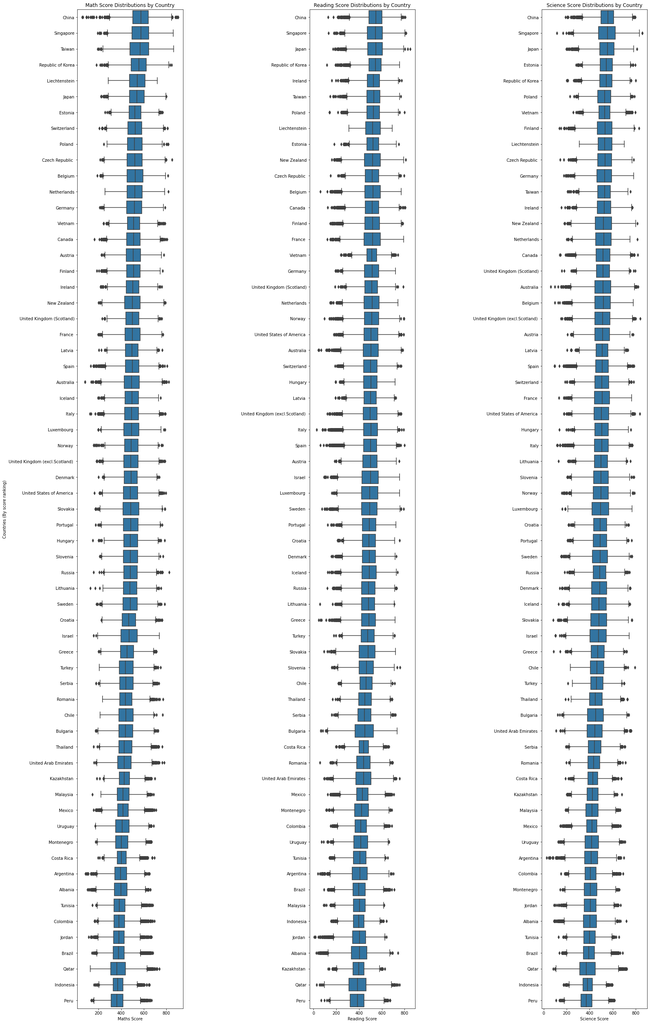

## Instrumental Motivation Ratings Vs Total Test Scores

> Those who strongly disagreed on all 4 modes of motivation got the lowest scores which might the reason of low scores. I used the point plot since I was trying to see the relationship between the Instrumental Motivation and the Total scores of the tests. This gave me a visual representation of how the students performed against their scores.

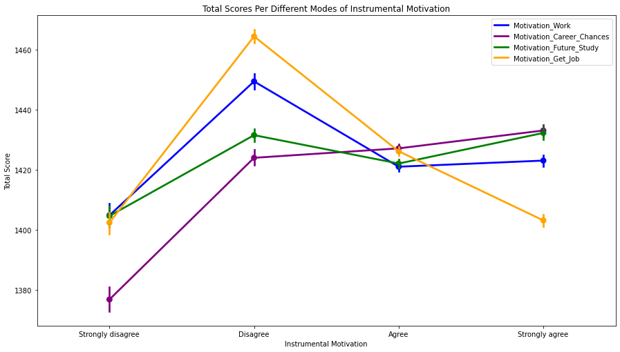